# QSM I Assignment 1, Question 1

Group names: Susana Casanova, Francis McAdie, Cai Stead, Daisy Xiao

## Packages and loading the data

```r
library(readxl)    # reads Excel files
library(lmtest)    # coeftest(), bptest(), resettest()
library(car)       # linearHypothesis(), vif()
library(sandwich)  # vcovHC(): robust standard errors
cars <- as.data.frame(read_excel("C:/Users/Ding/OneDrive/Documents/BSE_Masters/Term_1/Q&S/data_problemset1.xls", sheet = "Car Prices"))
names(cars) <- c("CC", "HP", "Year", "Km", "Gas", "ABS", "ABD",
                 "CD", "AW", "AC", "MP", "Price")
colSums(is.na(cars))
```

```
##    CC    HP  Year    Km   Gas   ABS   ABD    CD    AW    AC    MP Price
##     0     0     0     0     0     0     0     0     0     0     6     0
```

# (a) Simple model with kilometers as explanatory variable

> Estimate a simple model where the only explanatory variable is kilometres. Interpret the parameter values and t-statistics, the R² and the F-value.

## The model

A simple model where the only explanatory variable is kilometers:

$$Price_i = \beta_0 + \beta_1\,Km_i +
\varepsilon_i$$

## Code

```r
m1 <- lm(Price ~ Km, data = cars)
summary(m1)
```

```
##
## Call:
## lm(formula = Price ~ Km, data = cars)
##
## Residuals:
##      Min       1Q   Median       3Q      Max
## -14122.8  -3466.4   -533.8   2912.6  20163.9
##
## Coefficients:
##               Estimate Std. Error t value Pr(>|t|)
## (Intercept)  2.500e+04  1.610e+03  15.529  < 2e-16 ***
## Km          -9.962e-02  1.439e-02  -6.923 1.53e-09 ***
## ---
## Signif. codes:  0 '***' 0.001 '**' 0.01 '*' 0.05 '.' 0.1 ' ' 1
##
## Residual standard error: 6307 on 72 degrees of freedom
## Multiple R-squared:  0.3997, Adjusted R-squared:  0.3913
## F-statistic: 47.93 on 1 and 72 DF,  p-value: 1.529e-09
```

## Interpretation of output

**Parameter values**

- **Slope, $\hat\beta_1$ = -0.0996.** Each extra kilometre lowers the expected price by about 0.1 euros, so every 10,000 km costs about 996 euros.
- **Intercept, $\hat\beta_0$ = 25,001.** The predicted price of a car with 0 km, roughly a nearly new car. But only 1 car has under 10,000 km, so this is an extrapolation and not very meaningful on its own.

**T-statistics: Are the parameters significant?**

The t-statistic tests $H_0: \beta_j = 0$ (the variable has no effect):

$$t =
\frac{\hat\beta_j}{SE(\hat\beta_j)}$$

It counts how many standard errors the estimate lies from zero. If $|t| > 1.96$ (roughly 2), the p-value is below 0.05 and we reject $H_0$ at the 5% level.

- **Kilometers:** $t$ = -6.92, which is far beyond ±1.96, so the p-value is essentially 0 (1.53e-09). We reject the null hypothesis that mileage does not affect price.
- **Intercept:** $t$ = 15.53, which is also significant, however the null hypothesis that the price of a 0 km car is zero is not particularly relevant.

**R² and the F-value**

- **R² = 0.4.** Kilometres alone explain about 40% of the price differences, so about 60% is due to other factors.
- **F = 47.93.** The F-test checks whether all slope coefficients are zero at once. Since the p-value is essentially 0 (1.529e-09), the model has significant explanatory power.

# (b) A confidence interval for the effect of kilometres

> Construct and interpret a confidence interval for the marginal effect of kilometres.

## A 95% confidence interval

$$\hat\beta_1 \pm t_{0.975,\,N-2} \times
SE(\hat\beta_1)$$

$t_{0.975,\,N-2}$ is the critical value from the Student-t distribution with $N-2$ degrees of freedom (close to 1.96 in large samples). The interval also equals the set of values of $\beta_1$ that a 5% test would not reject.

## Code

```r
confint(m1, level = 0.95)
```

```
##                     2.5 %        97.5 %
## (Intercept) 21791.8100858  2.821072e+04
## Km             -0.1283057 -7.093773e-02
```

```r
ci <- confint(m1)[2, ]
crit <- qt(0.975, df = df.residual(m1))
```

## Interpretation of output

If we were to take repeated random samples and construct confidence intervals from them, 95% of those intervals would capture the true population parameter. For our specific sample, each extra 10,000 km lowers the expected price by between 709 and 1,283 euros.

Notes:

- Zero is far outside the interval, consistent with the large t-statistic found in Part a).
- The critical value is 1.993 rather than 1.96 because the sample is small, as the t-distribution has fatter tails.
- A dealer can say “10,000 extra km typically takes between 709 and 1,283 euros off the price.”

# (c) Residuals against kilometers

> Graph the residuals against kilometres. Do you see any evidence of a nonlinear effect? Explain what could cause it. Test whether the effect is nonlinear and interpret the test. How would you modify the model?

## Code

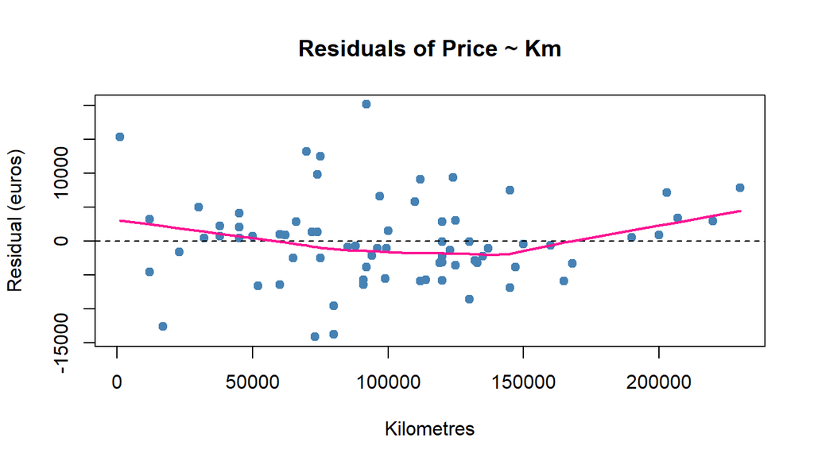

```r
cars$res_a <- resid(m1)

plot(cars$Km, cars$res_a, pch = 19, col = "steelblue",
     xlab = "Kilometres", ylab = "Residual (euros)",
     main = "Residuals of Price ~ Km")
abline(h = 0, lty = 2)
lines(lowess(cars$Km, cars$res_a), col = "deeppink", lwd = 2)
```

## Interpretation of Graph

The pink curve shows a slight **U** shape (non-liner effect): This shows that low-mileage and externally high-mileage cars on average sit above zero, while the middle-mileage cars are bellow. suggesting that the prices falls fast in the first Km’s then flattens out.

**What could cause it?**

An **omitted variable** could cause this non-liner effect: Most likely Age/Year of the car as the older the car the more Km’s it will have (correlation between Km and Year = -0.66).

Another option is a **genuine deprecation curve**: Meaning the true relationship is convex curve not a line.

## the test

To test for linearity we can use: * **The Ramsey’s RESET test** that adds powers of the fitted values ($\hat y^2$, $\hat y^3$) to the model and F-tests whether they help. $H_0$: the linear model works. * **A quadratic term.** In $Price = \beta_0 + \beta_1 Km + \beta_2 Km^2 + \varepsilon$, the t-test of $H_0: \beta_2 = 0$tests whether the effect of Km is linear.

## Code

```r
resettest(m1, power = 2:3, type = "fitted")
```

```
##
##  RESET test
##
## data:  m1
## RESET = 1.9889, df1 = 2, df2 = 70, p-value = 0.1445
```

```r
m_c <- lm(Price ~ Km + I(Km^2), data = cars)
summary(m_c)
```

```
##
## Call:
## lm(formula = Price ~ Km + I(Km^2), data = cars)
##
## Residuals:
##      Min       1Q   Median       3Q      Max
## -14887.0  -3230.0   -282.6   2385.4  21120.9
##
## Coefficients:
##               Estimate Std. Error t value Pr(>|t|)
## (Intercept)  2.871e+04  2.509e+03  11.442  < 2e-16 ***
## Km          -1.872e-01  4.811e-02  -3.891 0.000223 ***
## I(Km^2)      4.004e-07  2.103e-07   1.904 0.060915 .
## ---
## Signif. codes:  0 '***' 0.001 '**' 0.01 '*' 0.05 '.' 0.1 ' ' 1
##
## Residual standard error: 6195 on 71 degrees of freedom
## Multiple R-squared:  0.4288, Adjusted R-squared:  0.4128
## F-statistic: 26.65 on 2 and 71 DF,  p-value: 2.316e-09
```

## Interpretation the tests

The Ramsey RESET p-value = 0.145 and the p-value of the $Km^2$ term = 0.061. * At the 5% level (P = 0.05) **neither test rejects linearity** and the quadratic term is only significant at the 10% level, so the evidence for a curve is **weak**. * So currently the data doesn’t clearly show non-linearity.

**How to modify the model if the curve was significant:**

- **Add $Km^2$:** the marginal effect becomes $\beta_1 + 2\beta_2 Km$, so the effect of one more km depends on how many km the car already has.
- **Use log(Price):** each extra km then lowers the price by a constant **percentage**, which would give a larger drop in euros for expensive (low-mileage) cars.
- **Add Year:** if the curve mostly comes from the an omitted variable of age/Year, controlling for age/Year may remove it.

# (d) A more complete model

> Select a more complete model with other relevant variables. Interpret the parameters and t-stats of your final model. Test whether the additional variables have significant joint explanatory power.

## Code full model

```r
m_full <- lm(Price ~ Km + CC + HP + Year + Gas + ABS + ABD + CD + AW + AC + MP, data = cars)
summary(m_full)
```

```
##
## Call:
## lm(formula = Price ~ Km + CC + HP + Year + Gas + ABS + ABD +
##     CD + AW + AC + MP, data = cars)
##
## Residuals:
##     Min      1Q  Median      3Q     Max
## -5472.5 -2037.3   -11.9  1804.6 10492.2
##
## Coefficients:
##               Estimate Std. Error t value Pr(>|t|)
## (Intercept) -2.097e+06  3.438e+05  -6.099 1.05e-07 ***
## Km          -3.624e-02  1.053e-02  -3.441 0.001102 **
## CC          -2.559e-01  1.182e+00  -0.216 0.829476
## HP           8.186e+01  1.473e+01   5.557 7.91e-07 ***
## Year         1.055e+03  1.722e+02   6.126 9.48e-08 ***
## Gas         -4.114e+03  1.053e+03  -3.908 0.000253 ***
## ABS         -7.813e+02  1.574e+03  -0.496 0.621504
## ABD          1.612e+03  1.299e+03   1.241 0.219669
## CD          -3.296e+02  9.560e+02  -0.345 0.731584
## AW           3.537e+02  1.157e+03   0.306 0.760951
## AC           1.368e+03  9.289e+02   1.473 0.146436
## MP           8.914e+02  1.253e+03   0.712 0.479646
## ---
## Signif. codes:  0 '***' 0.001 '**' 0.01 '*' 0.05 '.' 0.1 ' ' 1
##
## Residual standard error: 3226 on 56 degrees of freedom
##   (6 observations deleted due to missingness)
## Multiple R-squared:  0.8716, Adjusted R-squared:  0.8464
## F-statistic: 34.55 on 11 and 56 DF,  p-value: < 2.2e-16
```

```r
vif(m_full)
```

```
##       Km       CC       HP     Year      Gas      ABS      ABD       CD
## 1.884490 3.879329 4.264962 3.135141 1.409324 1.494035 2.144926 1.487536
##       AW       AC       MP
## 1.185615 1.398489 1.285927
```

The results show Km, HP, Year and Gas are strongly significant. However, CC and all the dummies are not. * **CC and HP** are highly correlated (0.82): This makes sense as bigger engines are more powerful. Making it hard to separate their effects. So HP carries the effect, and CC adds nothing once HP is added in. * **Km’s effect shrinks** from -0.0996 in part (a) to -0.0362. So this is the omitted variable bias of Year: so if Year was left out, Km would still be impacted by the effect of age.

## Code final model

```r
m_comp <- lm(Price ~ Km + HP + Year + Gas, data = cars)
summary(m_comp)
```

```
##
## Call:
## lm(formula = Price ~ Km + HP + Year + Gas, data = cars)
##
## Residuals:
##     Min      1Q  Median      3Q     Max
## -5857.4 -1658.5  -465.8  1895.4 11133.7
##
## Coefficients:
##               Estimate Std. Error t value Pr(>|t|)
## (Intercept) -2.380e+06  2.527e+05  -9.418 5.21e-14 ***
## Km          -3.720e-02  9.485e-03  -3.922 0.000205 ***
## HP           7.515e+01  6.934e+00  10.837  < 2e-16 ***
## Year         1.197e+03  1.263e+02   9.484 3.96e-14 ***
## Gas         -3.845e+03  9.088e+02  -4.231 7.03e-05 ***
## ---
## Signif. codes:  0 '***' 0.001 '**' 0.01 '*' 0.05 '.' 0.1 ' ' 1
##
## Residual standard error: 3121 on 69 degrees of freedom
## Multiple R-squared:  0.8591, Adjusted R-squared:  0.851
## F-statistic: 105.2 on 4 and 69 DF,  p-value: < 2.2e-16
```

## Interpretation of Final model

| Variable | Estimate | t-stat | Meaning |
| --- | --- | --- | --- |
| Km | -0.0372 | -3.9 | Each extra 1,000 km lowers the price by about 37 € |
| HP | 75.1 | 10.8 | Each extra horsepower adds about 75 € so faster cars are more expensive |
| Year | 1197.4 | 9.5 | Each year newer adds about 1,197 € to the cars price |
| Gas | -3845.2 | -4.2 | A petrol car sells for about 3,845 € less than an otherwise identical diesel car |

**All 4 variables ar highly significant**

## Code joint tests

**Test 1: do the new variables add to the simple model?** $H_0: \beta_{HP} = \beta_{Year} = \beta_{Gas} = 0$. This is a **joint F-test** comparing the restricted model (a) with the unrestricted model (d):

$$F = \frac{(RSS_R -
RSS_U)/r}{RSS_U/(N-k-1)}$$
where r is the number of restrictions (3) and k the number of regressors in the bigger model. If adding the variables cuts the RSS a lot, F is large and we reject.

```r
anova(m1, m_comp)
```

| Res.Df | RSS | Df | Sum of Sq | F | Pr(>F) |
| --- | --- | --- | --- | --- | --- |
| 72 | 2863949805 | NA | NA | NA | NA |
| 69 | 671988926 | 3 | 2191960879 | 75.02371 | 0 |

```r
linearHypothesis(m_comp, c("HP = 0", "Year = 0", "Gas = 0"))
```

| Res.Df | RSS | Df | Sum of Sq | F | Pr(>F) |
| --- | --- | --- | --- | --- | --- |
| 72 | 2863949805 | NA | NA | NA | NA |
| 69 | 671988926 | 3 | 2191960879 | 75.02371 | 0 |

**Result:** F is very large and p ≈ 0, so we **reject** H0. So the added variables have strong joint explanatory power.

**Test 2: are the dropped variables jointly irrelevant?** This will justify simplifying from the full model.

```r
cars_cc <- na.omit(cars[, c("Price","Km","CC","HP","Year","Gas","ABS","ABD","CD","AW","AC","MP")])
m_fin <- lm(Price ~ Km + HP + Year + Gas, data = cars_cc)
m_f <- lm(Price ~ Km + CC + HP + Year + Gas + ABS + ABD + CD + AW + AC + MP, data = cars_cc)
anova(m_fin, m_f)
```

| Res.Df | RSS | Df | Sum of Sq | F | Pr(>F) |
| --- | --- | --- | --- | --- | --- |
| 63 | 637497385 | NA | NA | NA | NA |
| 56 | 582848141 | 7 | 54649244 | 0.7500992 | 0.6308921 |

**Result:** F = 0.75, p = 0.631. Since the P value is greater than 0.05 we can’t reject the H0. So the 7 omitted variables have jointly zero effect on the data. Therefore, removing them has no significant impact on the model.